## Practical Machine Learning Course Project

**Ben Niu**

### Executive Summary:

The task of this project is to predict the manner in which 6 participants did the exercises, as denoted as *“classe”* variable in the dataset. There are many variables in the original dataset, some of them are definitely more sensitive than others in predicting the outcome, so *Principal component analysis* might be necessary. **Model 1** used trees as classifier and showed that without PCA the accurary was relatively low. **Model 2** adopted PCA and showed improved accuracy. **Model 3** used boosting as classifier coupled with PCA, which turned out to have the highest accuracy. All training control used the *10-fold Cross Validation* without repeat.

### Analyses:

#### Data Prep

Loading the **ggplot2**, **caret**, **xtable** packages.

Download **training** and **testing** data, read and subset the data.

#### Predictor Selection

Use *near zero variance identification* to filter out less important variables.

```r
nzv<-nearZeroVar(TRAIN, saveMetrics=TRUE)
good.var<-subset(nzv, nzv=="FALSE")
TRAIN.goodvar<-subset(TRAIN, select=row.names(good.var))
```

Remove remaining variables with more than 50% being **“NA”**

```r
good<-NULL
for(i in 1:ncol(TRAIN.goodvar)){
  if(sum(is.na(as.character(TRAIN.goodvar[,i]))) < length(TRAIN.goodvar[,i])*0.5){
    good0<-names(TRAIN.goodvar)[i]
    good<-c(good, good0)}
}
TRAIN.goodvar<-subset(TRAIN.goodvar, select=good)
```

#### Model 1: Predict with trees (rpart) and K-fold cross validation, without PCA

```r
## Use 10-fold CV
set.seed(11445)
tc<-trainControl(method="cv", number=10)
## hold 20% of the training data to compute the accurary as a testimony of the model.
sub<-createDataPartition(y=TRAIN.goodvar$classe, p=0.8, list=FALSE)
train.sub<-TRAIN.goodvar[sub,]
val.sub<-TRAIN.goodvar[-sub,]
Model.rpart1<-train(train.sub$classe~., method="rpart", data=train.sub[,-58], trControl=tc)
```

|  | cp | Accuracy | Kappa | AccuracySD | KappaSD |
| --- | --- | --- | --- | --- | --- |
| 1 | 0.04 | 0.55 | 0.43 | 0.03 | 0.04 |
| 2 | 0.05 | 0.46 | 0.28 | 0.08 | 0.14 |
| 3 | 0.12 | 0.33 | 0.07 | 0.04 | 0.06 |

So the accuracy of *Model 1* is 0.55 by choosing the cp 0.040.

#### Model 2: Predict with trees (rpart) and K-fold cross validation, with PCA

```r
## Perform PCA to reduce variable dimensions.
## Use 10-fold CV
set.seed(11445)
tc<-trainControl(method="cv", number=10)
sub<-createDataPartition(y=TRAIN.goodvar$classe, p=0.8, list=FALSE)
train.sub<-TRAIN.goodvar[sub,]
val.sub<-TRAIN.goodvar[-sub,]
PCA<-preProcess(train.sub[,-58], method="pca",thresh=0.95)
PCA.train<-predict(PCA, train.sub[,-58])
Model.rpart2<-train(train.sub$classe~., method="rpart", data=PCA.train, trControl=tc)
```

|  | cp | Accuracy | Kappa | AccuracySD | KappaSD |
| --- | --- | --- | --- | --- | --- |
| 1 | 0.01 | 0.68 | 0.59 | 0.01 | 0.02 |
| 2 | 0.02 | 0.66 | 0.57 | 0.01 | 0.01 |
| 3 | 0.02 | 0.51 | 0.34 | 0.20 | 0.29 |

The accuracy of *Model 2* is 0.68 by choosing cp as 0.013.  
Figure showing how accuracy changes as cp is tuned:

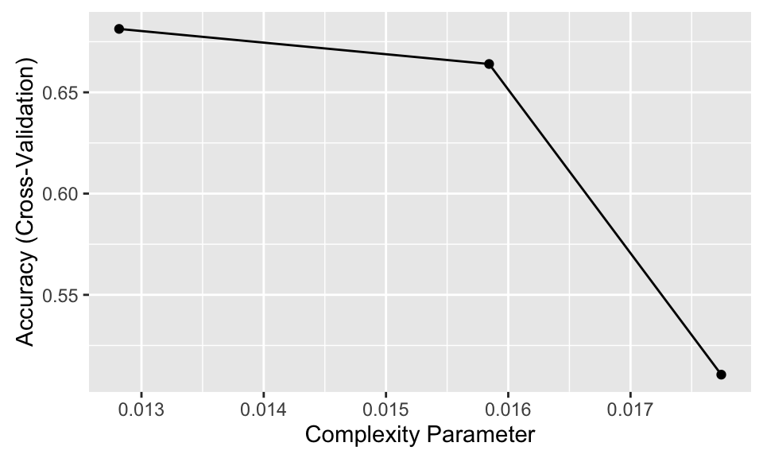

#### Model 3: Predict with Boosting (gbm) and K-fold CV, with PCA

```r
set.seed(11445)
tc<-trainControl(method="cv", number=10)
sub<-createDataPartition(y=TRAIN.goodvar$classe, p=0.8, list=FALSE)
train.sub<-TRAIN.goodvar[sub,]
val.sub<-TRAIN.goodvar[-sub,]
PCA<-preProcess(train.sub[,-58], method="pca",thresh=0.95)
PCA.train<-predict(PCA, train.sub[,-58])
Model.gbm<-train(train.sub$classe~., method="gbm", data=PCA.train, trControl=tc, verbose=FALSE)
```

|  | shrinkage | interaction.depth | n.minobsinnode | n.trees | Accuracy | Kappa | AccuracySD | KappaSD |
| --- | --- | --- | --- | --- | --- | --- | --- | --- |
| 1 | 0.10 | 1 | 10.00 | 50.00 | 0.71 | 0.64 | 0.01 | 0.02 |
| 4 | 0.10 | 2 | 10.00 | 50.00 | 0.79 | 0.73 | 0.01 | 0.02 |
| 7 | 0.10 | 3 | 10.00 | 50.00 | 0.84 | 0.80 | 0.01 | 0.01 |
| 2 | 0.10 | 1 | 10.00 | 100.00 | 0.76 | 0.70 | 0.01 | 0.01 |
| 5 | 0.10 | 2 | 10.00 | 100.00 | 0.85 | 0.81 | 0.01 | 0.01 |
| 8 | 0.10 | 3 | 10.00 | 100.00 | 0.89 | 0.86 | 0.00 | 0.00 |
| 3 | 0.10 | 1 | 10.00 | 150.00 | 0.79 | 0.74 | 0.01 | 0.01 |
| 6 | 0.10 | 2 | 10.00 | 150.00 | 0.87 | 0.84 | 0.01 | 0.01 |
| 9 | 0.10 | 3 | 10.00 | 150.00 | 0.91 | 0.89 | 0.01 | 0.01 |

The accuracy of *Model 3* can reach 0.91 with shrinkage being 0.1 constant, interaction depth being 3 and n.minobsinnode being 10, n.trees being 150.  
Figure showing details of *Model 3* is here:

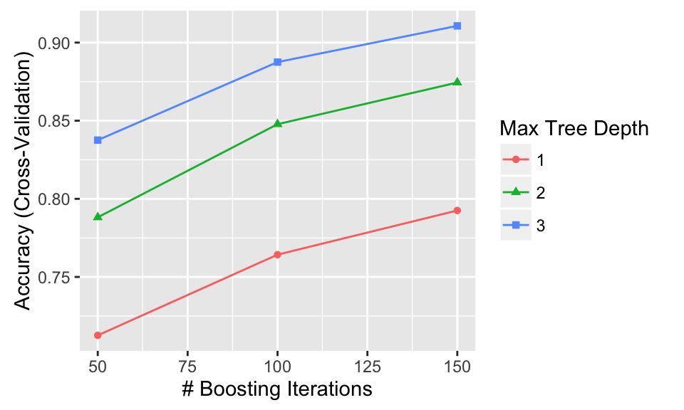

#### Conclusion

The table below showed the model accuracies, and the test outcomes by using the 20% hold-out samples.

|  | Model.Accuracy | Test.Accuracy |
| --- | --- | --- |
| Model 1 | 0.55 | 0.49 |
| Model 2 | 0.68 | 0.66 |
| Model 3 | 0.91 | 0.92 |

Clearly the *Model 3* that using Boosting is a much better classifier. This one should be applied to the real test dataset and predict.